# pres_Observability slides

## Output feedback control, Observability and observer design

### MEC 560: Advanced control systems

#### Vivek Yadav, PhD

## Recap

- State space representation
- Controllability
- Pole-placement for different control applications
- Optimal control formulation
- Linear quadratic regulator (LQR) control formulation (first variance principles)
- Dynamic programming for LQR
  - Path planning
  - LQR using dynamic programming
- Multiple shooting
- Direct collocation

All techniques above assume that the states are known, which need not be true.

## Output feedback control

Consider a system given by

$$ \frac{d x }{dt} = A x + B u $$

with measurements

$$ y = C x. $$

We design a controller \( u = -Ky \). The system dynamics becomes,

$$ \frac{d x }{dt} = (A - BKC) X $$

### Motivaitng example

Consider the system given by,

$$ \dot{X} = \left[ \begin{array}{cc} 0 & 1 \\ 0 & 0 \end{array} \right] X + \left[ \begin{array}{c} 0 \\ 1 \end{array} \right] u $$

with measurement

$$ y = \left[ \begin{array}{cc} 1 & 0 \end{array} \right] X . $$

and control

$$ u = -Ky = - KCX $$

where \( K = 1 \).

The \( (A - BKC) \) matrix in this case is,

$$ A-BKC = \left[ \begin{array}{cc} 0 & 1 \\ 0 & 0 \end{array} \right] - \left[ \begin{array}{c} 0 \\ 1 \end{array} \right] \times 1 \times \left[ \begin{array}{cc} 1 & 0 \end{array} \right] = \left[ \begin{array}{cc} 0 & 1 \\ -1 & 0 \end{array} \right]$$

```matlab
A = [0 1 ; 0 0];
B = [0 ; 1];
C = [1 0];

X0 = [1;0];
t = 0:0.01:10;

K = 1;


sys_OFC = @(t,X)[A*X - B*K*C*X]

[t,X] = ode45(sys_OFC,t,X0);
```

```
sys_OFC =

    @(t,X)[A*X-B*K*C*X]
```

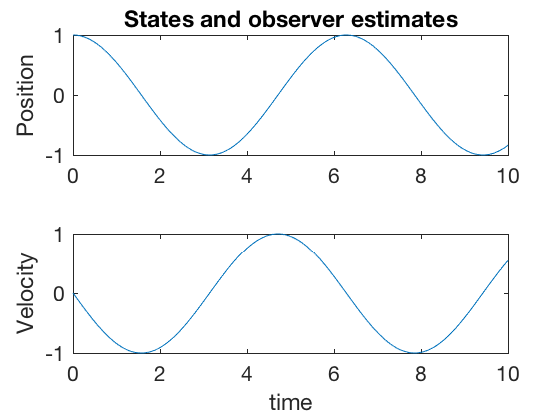

```matlab
figure;
subplot(2,1,1)
plot(t,X(:,1))
title('States and observer estimates')
ylabel('Position')
subplot(2,1,2)
plot(t,X(:,2))
ylabel('Velocity')
xlabel('time')
```

- Stabilization of state variables is not possible if \( A - BKC \) does not have eigen values with negative real parts.
- Information about more states (than measured) is needed to design controllers.

Observers allow us to estimate all the states of the system in cases where only partial measurements are available.

Observability concepts allow us to determine if all the states of the system can be estimated given the system and measurement variables.

## Observer

$$ \frac{d x }{dt} = A x + B u $$

with measurements

$$ y = C x + Du. $$

#### Observer objective

Obtain an estimate \( \hat{x} \) of the states \( x \) such that \( (x - \hat{x}) \) is as small as possible

## Question: Is observer design always possible?

System

$$ \dot{X} = \left[ \begin{array}{cc} 0 & 1 \\ 0 & 0 \end{array} \right] X + \left[ \begin{array}{c} 0 \\ 1 \end{array} \right] u . $$

with measurement

$$ y = C X . $$

##### 1. \( C = \left[ \begin{array}{cc} 1 & 0 \end{array} \right] \)

##### 2. \( C = \left[ \begin{array}{cc} 1 & 1 \end{array} \right] \)

##### 3. \( C = \left[ \begin{array}{cc} 0 & 1 \end{array} \right] \)

## Question: Is observer design always possible?

System

$$ \dot{X} = \left[ \begin{array}{cc} 0 & 1 \\ 0 & 0 \end{array} \right] X + \left[ \begin{array}{c} 0 \\ 1 \end{array} \right] u . $$

with measurement

$$ y = C X . $$

##### 1. \( C = \left[ \begin{array}{cc} 1 & 0 \end{array} \right] \) : Observable

##### 2. \( C = \left[ \begin{array}{cc} 1 & 1 \end{array} \right] \) : Observable

##### 3. \( C = \left[ \begin{array}{cc} 0 & 1 \end{array} \right] \) : NOT Observable

As position cannot accurately be reconstructed using velocity alone without knowing initial conditions.

Observability concepts allow us to identify if observer design is possible.

## Observability

Observability is used to determine given the set of measurement variables, can we estimate the states of the system. An unforced system is said to be observable if for a given if and only if it is possible to determine the initial state x(0) by using only a finite history of measurements \( y( \tau)\) for \(0\leq \tau \leq T \) for any time \( T \).

##### Observability of a continuous linear system

An unforced linear system is given by

$$ \frac{d x(t) }{dt} = A x(t),$$

and

$$ y(t) = C x(t),$$

Taking successive derivatives of the measurement,

$$ \begin{array}{c} \dot{y}(t)= C \dot{x}(t) = CA x_0 ,\\ \ddot{y}(t)= CA \dot{x}(t) = CA^2 x_0 ,\\ \vdots \\ y^{(n-1)}(t)= C A^{n-2} \dot{x}(t) = CA^{n-1} x_0 ,\\ \end{array}$$

$$ \left[ \begin{array}{c} y(t)\\ \dot{y}(t)\\ \vdots \\ y^{(n-1)}(t)\\ \end{array} \right] = \underbrace{\left[ \begin{array}{c} C \\ CA \\ \vdots \\ CA^{n-1} \\ \end{array} \right]}_{observability~matrix} x_0.$$

It is possible to solve for \(x_0\) for a given measurement history only if the observability matrix is of rank \(n\).

##### Observability of a discrete linear system

An unforced discrete linear system is given by

$$ x[k+1] = A x[k],$$

and

$$ y[k] = C x[k],$$

Taking successive values of the measurement,

$$ \begin{array}{c} y[0] = C x[0] ,\\ y[1] = C x[1]= C A x[0] ,\\ y[2] = C x[2]= C A^2 x[0] ,\\ \vdots \\ y[n-1] = C x[n-2]= C A^{n-1} x[0]\\ \end{array}$$

Rewriting in matrix form,

$$ \left[ \begin{array}{c} y[0] \\ y[1] \\ \vdots \\ y[n-1] \\ \end{array} \right] = \underbrace{\left[ \begin{array}{c} C \\ CA \\ \vdots \\ CA^{n-1} \\ \end{array} \right]}_{observability~matrix} x[0] .$$

It is possible to solve for \(x_0\) for a given measurement history only if the observability matrix of is rank \(n\).

#### Grammian form

Obsearvability is also expressed via a Grammian matrix Q,

$$ Q(T) = \int_{0}^{T} e^{ A^T \lambda } C^T C e^{A \lambda } d\lambda . $$

If \( Q(T) \) is non-singular for all \( T\) then the underlying dynamic system is observable.

#### Another form of observability matrix

As matrix and its transpose have the same rank, we can use the matrix

$$ \left[ \begin{array}{ccccc} C^T & A^T C^T & (A^T)^2 C^T & \dots & (A^T)^{n-1} C^T \end{array} \right] $$

to compute rank of the observability matrix.

##### When do systems become unobservable?

- Have unobservable system is more common than uncontrollable system.
- Poor sensor choice can result in system becoming unobservable.
- A system becomes unobservable a state variable is not measured and directly and is not fed back to those state variables that are measured. Consider the following control system,

$$ \dot{x_1} = A_1 x_1 + B_1u $$

$$ \dot{x_2} = A_{12} x_1 + A_{22} x_2 + B_2 u $$

with measurement \(y = x_1\). This system can only measure \( x_1 \) and altough it may be possible to control \( x_2 \) by applying appropriate control \( u \), design of such a control is impossible because there is no direct or indirect measure of \(x_2\).

## Observability example

Consider the system given by,

$$ \dot{X} = \left[ \begin{array}{cc} 0 & 1 \\ 0 & 0 \end{array} \right] X + \left[ \begin{array}{c} 0 \\ 1 \end{array} \right] u . $$

with measurement

$$ y = C X . $$

##### 1. \( C = \left[ \begin{array}{cc} 1 & 0 \end{array} \right] \)

##### 2. \( C = \left[ \begin{array}{cc} 1 & 1 \end{array} \right] \)

##### 3. \( C = \left[ \begin{array}{cc} 0 & 1 \end{array} \right] \)

Observability matrix can be written as,

$$ Obs(A,C) = \left[ \begin{array}{c} C \\ C A \end{array} \right] $$

##### 1. \( C = \left[ \begin{array}{cc} 1 & 0 \end{array} \right] \)

Observability matrix in this case is,

$$ Obs(A,C) = \left[ \begin{array}{cc} \left[ \begin{array}{cc} 1 & 0 \end{array} \right] \\ \left[ \begin{array}{cc} 1 & 0 \end{array} \right] \left[ \begin{array}{cc} 0 & 1 \\ 0 & 0 \end{array} \right] \end{array} \right]$$$$ Obs(A,C) = \left[ \begin{array}{cc} 1 & 0 \\ 0 & 1 \end{array} \right] $$

Rank of observability matrix is 2, so the system is measurable if we have measure of position. This is intuitive, given position, we can estimate velocity by differentiation.

##### 2. \( C = \left[ \begin{array}{cc} 1 & 1 \end{array} \right] \)

As our measurement has information on both position and velocity, we should be able to reconstruct both positions and velocity. Observability matrix in this case is,

$$ Obs(A,C) = \left[ \begin{array}{cc} \left[ \begin{array}{cc} 1 & 1 \end{array} \right] \\ \left[ \begin{array}{cc} 1 & 1 \end{array} \right] \left[ \begin{array}{cc} 0 & 1 \\ 0 & 0 \end{array} \right] \end{array} \right]$$$$ Obs(A,C) = \left[ \begin{array}{cc} 1 & 1 \\ 0 & 1 \end{array} \right] $$

Rank of observability matrix is 2, so the system is measurable if we have measure of position.

##### 3. \( C = \left[ \begin{array}{cc} 0 & 1 \end{array} \right] \)

$$ Obs(A,C) = \left[ \begin{array}{cc} \left[ \begin{array}{cc} 0 & 1 \end{array} \right] \\ \left[ \begin{array}{cc} 0 & 1 \end{array} \right] \left[ \begin{array}{cc} 0 & 1 \\ 0 & 0 \end{array} \right] \end{array} \right]$$$$ Obs(A,C) = \left[ \begin{array}{cc} 0 & 1 \\ 0 & 0 \end{array} \right] $$

## Observer design

Two pole-placement based observers

1. Full-state (or Full-order) observer : Estimate the full state space
2. Reduced-order observer : Compute the measured states directly, and estimate unmeasured

### Full-observer design

We now design observer for the system given by,

$$ \dot{X} = AX + Bu $$

with measurement,

$$ y = CX + Du . $$

Knowns: measurement \( y \), the control \( u \) Unknowns: Actual state \( X \)

We design an observer to estimate \( X \) as

$$ \dot{\hat{X}} = A\hat{X} + Bu + L (y - \hat{y}) $$

where \( \hat{y} \) is the approximate value of measurement, and is described as

$$ \hat{y} = C \hat{X} + Du . $$

In the system above, the goal is to choose an \(L\) such that \( \hat{X} \rightarrow X \).

#### Observer error

Substituting expressions for \( y \) and \( \hat{y} \) in the observer equation gives,

$$ \dot{\hat{X}} = A\hat{X} + Bu + L (y - \hat{y}) $$$$ \dot{\hat{X}} = A\hat{X} + Bu + L \left( CX + Du - ( C \hat{X} + Du)\right) $$$$ \dot{\hat{X}} = A\hat{X} + Bu + L C ( X - \hat{X}) $$

The error between the state and its estimate is \( e = X - \hat{X} \), therefore, substracting system dynamics from the observer equation above gives,

$$ \dot{X} - \dot{\hat{X}} = A( X - \hat{X} ) - L C ( X - \hat{X}) $$$$ \dot{e} = (A - L C )e $$

As eigen values of matrix are the same as its transpose,

$$ eig(A - LC ) = eig\left( (A - LC )^T \right) = eig(A^T - C^TL^T )$$

The problem of placing poles for \( \left( A^T - C^TL^T \right) \), is same as pole-placement for \( ( A - BK ) \) in the controller design. Therefore, we can use the same method as before with \( A \) and \( B \) replaced by \( A^T \) and \( C^T \) respectively. \( L \) can be computed from \( L = K^T \).

### Full-order observer example

$$ \dot{X} = \left[ \begin{array}{cc} 0 & 1 \\ 0 & 0 \end{array} \right] X + \left[ \begin{array}{c} 0 \\ 1 \end{array} \right] u $$$$ y = \left[ \begin{array}{cc} 1 & 0 \end{array} \right] X . $$

Design observer and choose \( L \) such that eigen values of \( (A - LC) \) are -2 and -3.

```matlab
%% Observer design example

clc
close all
clear all


A = [0 1 ; 0 0];
B = [0 ; 1];
C = [1 0];

p = [-2;-3];

L_t = place(A',C',p);
L = L_t';
t = 0:0.001:5;
dt = t(2) - t(1);
X(:,1) = [1;1];
y(:,1) = C*X;

X_hat(:,1) = [0;0];
y_hat(:,1) = C*X_hat;
for i = 2:length(t)
    u = .5;

    X(:,i) = X(:,i-1)  +dt * (A*X(:,i-1) + B*u);
    y(:,i) = C*X(:,i) ;

    X_hat(:,i) = X_hat(:,i-1)  +dt * (A*X_hat(:,i-1) + B*u +L*(y(:,i-1)-y_hat(:,i-1)));
    y_hat(:,i) = C*X_hat(:,i) ;
end
```

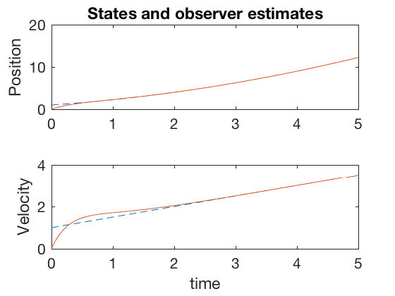

```matlab
figure;
subplot(2,1,1)
plot(t,X(1,:),'--',t,X_hat(1,:))
title('States and observer estimates')
ylabel('Position')
subplot(2,1,2)
plot(t,X(2,:),'--',t,X_hat(2,:))
ylabel('Velocity')
xlabel('time')
```

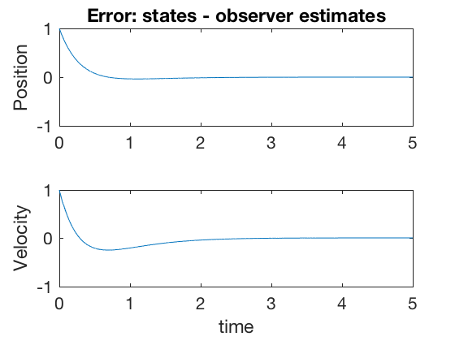

```matlab
figure;
subplot(2,1,1)
plot(t,X(1,:)-X_hat(1,:))
ylabel('Position')
title('Error: states - observer estimates')
subplot(2,1,2)
plot(t,X(2,:)-X_hat(2,:))
ylabel('Velocity')
xlabel('time')
```

### Reduced-order observer design.

Error in measured state was not 0. Therefore, full-order observer is not ideal. Reduced order observer computes the measured state, and estimates the unknown state.

$$ \dot{X} = AX + Bu $$

with measurement,

$$ y = CX + Du . $$

We assume that we have a \( n\)-dimensional state vector and an \( p (< n) \) dimensional measurement vector. A reduced-order observer is constructed in following steps,

Reduced-order observer design: Steps

1. Transform system: Apply similarity transform to convert C as \( [ I ~ 0 ] \)
2. Partition the state space: Into measured and unmeasured states
3. Observer design: Design observer to estimate unmeasured states

#### 1. Tranform system

Find a transformation \( P \) such that after transformation \( X = PZ \), the system dynamics change as

$$ \dot{Z} = A_z Z + B_zu $$

with measurement,

$$ y = Z_1 + D u, $$

where the new transformed state-space is

$$ Z = \left[ \begin{array}{c} Z_1 \\ Z_2 \end{array} \right]. $$

The transformation \( P \) can be found as follows,

1. Perform elementary column operations to find a nonsingulr matrix R of dimensions \( p \times n \) such that \( CR = \left[ \begin{array}{cc} C_1 & 0 \end{array} \right] \), where \( C_1 \) is an invertible \( p \) dimensional matrix.
2. Choose, $$ P = R \left[ \begin{array}{cc} C_1^{-1} & 0 \\ 0 & I_{n-p} \end{array} \right] $$ Now

   $$ C P = CR \left[ \begin{array}{cc} C_1^{-1} & 0 \\ 0 & I_{n-p} \end{array} \right] = [I_p 0] $$

Using \( P \) above for transormation \( X = PZ \) the system,

$$ \dot{X} = AX + Bu $$

with measurement,

$$ y = CX + Du . $$

transforms as,

$$ \dot{Z} = \underbrace{P^{-1} A P}_{A_z} Z + \underbrace{P^{-1}B}_{B_z} u $$

with measurement,

$$ y = CPZ + D u = Z_1 + Du. $$

#### 2. Partition the state space.

Partition the state space as,

$$ \left[ \begin{array}{c} \dot{Z}_1 \\ \dot{Z}_2 \end{array} \right] = \left[ \begin{array}{cc} A_{z,11} & A_{z,12} \\ A_{z,21} & A_{z,22} \end{array} \right] \left[ \begin{array}{c} Z_1 \\ Z_2 \end{array} \right] + \left[ \begin{array}{c} B_{z,1} \\ B_{z,2} \end{array} \right] u $$

With measurements,

$$ y = Z_1 + Du $$

Expand and rewrite the state space equation as,

$$ \dot{Z}_1 = A_{z,11} Z_1 +A_{z,12} Z_2 + B_{z,1} u $$

$$ \dot{Z}_2 = A_{z,21} Z_1 +A_{z,22} Z_2 + B_{z,2} u $$

In the partioned state space above, we have direct measure of \( Z_1 \), so we need to design measurement for \( Z_2 \) only.

#### 3. Observer design.

We design an observer to estimate \( \hat{K}_z \) such that \( \hat{Z}_2 \rightarrow Z_2 \) as \( t \rightarrow \infty \). Consider the system given by,

$$ \dot{\hat{Z}}_2 = A_{z,21} Z_1 +A_{z,22} \hat{Z}_2 + B_{z,2} u + K_z \left( \dot{Z}_1 - A_{z,11} Z_1 - A_{z,12} \hat{Z}_2 - B_{z,1} u \right) $$

The error dynamics between ( \hat{Z}_2 \) and \( Z_2 \) is

$$ \dot{Z}_2 - \dot{\hat{Z}}_2 = A_{z,21} Z_1 +A_{z,22} Z_2 + B_{z,2} u - \left( A_{z,21} Z_1 +A_{z,22} \hat{Z}_2 + B_{z,2} u + K_z \left( \dot{Z}_1 - A_{z,11} Z_1 - A_{z,12} \hat{Z}_2 - B_{z,1} u \right) \right) $$

$$ \dot{Z}_2 - \dot{\hat{Z}}_2 = A_{z,22} (Z_2 - \hat{Z}_2) - K_z \left( \dot{Z}_1 - A_{z,11} Z_1 - A_{z,12} \hat{Z}_2 - B_{z,1} u \right) $$

Substituting \( \dot{Z}_1 \) from partitioned equations gives,

$$ \dot{Z}_2 - \dot{\hat{Z}}_2 = A_{z,22} (Z_2 - \hat{Z}_2) - K_z \left( \left(A_{z,11} Z_1 +A_{z,12} Z_2 + B_{z,1} u \right) - A_{z,11} Z_1 - A_{z,12} \hat{Z}_2 - B_{z,1} u \right) $$

$$ \dot{Z}_2 - \dot{\hat{Z}}_2 = A_{z,22} (Z_2 - \hat{Z}_2) - K_z \left( A_{z,12} (Z_2 - \hat{Z}_2 ) \right) $$

Defining error \( e = (Z_2 - \hat{Z}_2) \),

$$ \dot{e} = \left( A_{z,22} - K_z A_{z,12} \right) e $$

Choose \( K_z \) such that the poles of the resulting system have negative real parts

Therefore, \( Z_2 \) in

$$ \dot{Z}_2 = A_{z,21} Z_1 +A_{z,22} Z_2 + B_{z,2} u , $$

can be estimated using

$$ \dot{\hat{Z}}_2 = A_{z,21} Z_1 +A_{z,22} \hat{Z}_2 + B_{z,2} u + K_z \left( \dot{Z}_1 - A_{z,11} Z_1 - A_{z,12} \hat{Z}_2 - B_{z,1} u \right) $$

where

$$ y = Z_1 + Du $$

However, the expression above, we need to compute derivative of \( Z_1 \), this can be obtaining by applying another transformation, such that

$$ w = \hat{Z}_2 - K_z Z_1$$

Taking derivative gives,

$$ \dot{w} = \dot{\hat{Z}}_2 - K_z \dot{Z}_1$$

$$ \dot{w} = ( A_{z,22} - K_z A_{z,12} ) w + ( B_{z,2} - K_z B_{z,1} )u + (A_{z,21} - K_z A_{z,11} + A_{z,22} K_z - K_z A_{z,12} K_z) Z_1 $$

### Final reduced-order observer

The final reduced order observer is given as,

$$ \dot{w} = ( A_{z,22} - K_z A_{z,12} ) w + ( B_{z,2} - K_z B_{z,1} )u + (A_{z,21} - K_z A_{z,11} + A_{z,22} K_z - K_z A_{z,12} K_z) Z_1 $$

The original state-space representation can be reconstructed using

$$ X = P Z = P \left[ \begin{array}{c} Z_1 \\ w + K_z Z_1 \end{array} \right]$$

Where \( K_z \) is chosen such that

$$ ( A_{z,22} - K_z A_{z,12}) $$

has negative real parts of eigen values.

### Example 1: Reduced-order observer

Consider the system given by,

$$ \dot{X} = \left[ \begin{array}{cc} 0 & 1 \\ 0 & 0 \end{array} \right] X + \left[ \begin{array}{c} 0 \\ 1 \end{array} \right] u $$

with measurement

$$ y = \left[ \begin{array}{cc} 1 & 1 \end{array} \right] X . $$

Note, measurement is sum of position and velocity.

#### 1. Transform system

In this case, as \( C \) is in the form

$$\left[ \begin{array}{cc} 1 & 1 \end{array} \right] , $$

we to apply a similarity transformation.

$$R = \left[ \begin{array}{cc} .5 & .5 \\ .5 & -.5 \end{array} \right] , $$

when multiplied by \( C \) gives,

$$C R = \left[ \begin{array}{cc} 1 & 1 \end{array} \right]\left[ \begin{array}{cc} .5 & .5 \\ .5 & -.5 \end{array} \right] = \left[ \begin{array}{cc} 1 & 0 \end{array} \right] $$

where

$$ C_z = 1 . $$

We therefore choose \( P \) as,

$$ P = R \left[ \begin{array}{cc} C_1^{-1} & 0 \\ 0 & I_{n-p} \end{array} \right] $$$$ P = \left[ \begin{array}{cc} .5 & .5 \\ .5 & -.5 \end{array} \right] \left[ \begin{array}{cc} 1 & 0 \\ 0 & 1 \end{array} \right] = \left[ \begin{array}{cc} .5 & .5 \\ .5 & -.5 \end{array} \right] $$

Applying the transformation,

$$ X = P Z = \left[ \begin{array}{cc} .5 & .5 \\ .5 & -.5 \end{array} \right] Z $$

gives,

$$ \dot{Z} = \underbrace{P^{-1} A P}_{A_z} Z + \underbrace{P^{-1}B}_{B_z} u $$

And the measurement equation is,

$$ y = CPZ $$

$$ y = \left[ \begin{array}{cc} 1 & 1 \end{array} \right] \left[ \begin{array}{cc} .5 & .5 \\ .5 & -.5 \end{array} \right] Z = \left[ \begin{array}{cc} 1 & 0 \end{array} \right] Z= Z_1$$

#### 2. Partition state space

We next partition the state space in the form,

$$ \dot{Z}_1 = A_{z,11} Z_1 +A_{z,12} Z_2 + B_{z,1} u $$

$$ \dot{Z}_2 = A_{z,21} Z_1 +A_{z,22} Z_2 + B_{z,2} u $$

$$ \left[ \begin{array}{c}\dot{Z}_1 \\ \dot{Z}_2 \end{array} \right] = \left[ \begin{array}{cc} .5 & -.5 \\ .5 & -.5 \end{array} \right] \left[ \begin{array}{c} Z_1 \\ Z_2 \end{array} \right] + \left[ \begin{array}{c} 1 \\ -1 \end{array} \right] u $$

We get,

$$ A_{z,11} = .5 $$$$ A_{z,12} = -.5$$$$ A_{z,21} = .5$$$$ A_{z,22} = -.5 $$

#### 3. Choose gain for observer

We next choose \( K_z \) such that the eigen values of

$$ \left(A_{z,22} - K_z A_{z,12} \right) $$

Therefore \( K_z = -3 \) places poles of the system at -2.

#### 4. Final reduced-order observer

In expression above, we have direct measure of \( Z_1 \) so the expression above becomes,

```matlab
clc
close all
clear all

P = [.5 .5 ; .5 -.5];
A = [0 1 ; 0 0];
B = [0;1];
C = [1 1];

display(['Observability matrix''s rank is ' num2str(rank(obsv(A,C))) '.' ])
A_z = inv(P)*A*P;
B_z = inv(P)*B;
C_z = C*P;

p = 1;
n = size(A,1);

A_z11 = A_z(1:p,1:p);A_z12 = A_z(1:p,p+1:n);
A_z21 = A_z(p+1:n,1:p);A_z22 = A_z(p+1:n,p+1:n);

B_z1 = B_z(1:p);B_z2 = B_z(p+1:n);
K_z = -3;

poles_sys = A_z22 - K_z*A_z12;
display(['Poles of the observer system are at ' num2str(poles_sys) '.' ])

A_w2 = A_z22 - K_z*A_z12;
A_wz1 = A_z21 - K_z*A_z11 + A_z22*K_z - K_z*A_z12*K_z;
B_wz = B_z2 - K_z*B_z1;
```

```
Observability matrix's rank is 2.
Poles of the observer system are at -2.
```

```matlab
display(['Modified observer system is dw = ' num2str(A_w2) 'w +' num2str(A_wz1) 'z1 + '  num2str(B_wz) 'u' '.' ])
t = 0:0.001:4;
dt = t(2) - t(1);
X(:,1) = [1;1];
y(:,1) = C*X;
Z_1(:,1) = y(:,1);
w(:,1) = 0;
Z_2(:,1) = K_z*Z_1(:,1)+w(:,1);
X_hat(:,1) = P*[Z_1(:,1);Z_2(:,1);];

for i = 2:length(t)
    u = .5;
    X(:,i) = X(:,i-1)  +dt * (A*X(:,i-1) + B*u);
    y(:,i) = C*X(:,i) ;
    Z_1(:,i) = y(:,i);
    w(:,i) = w(:,i-1) + dt* ( A_w2*w(:,i-1) + A_wz1*Z_1(:,i-1) + B_wz * u) ;
    Z_2(:,i) = K_z*Z_1(:,i)+w(:,i);
   X_hat(:,i) = P*[Z_1(:,i);Z_2(:,i);];
end
```

```
Modified observer system is dw = -2w +8z1 + 2u.
```

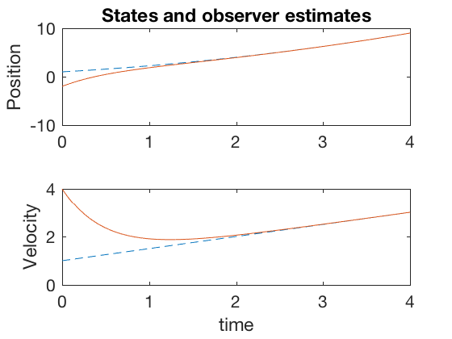

```matlab
figure;
subplot(2,1,1)
plot(t,X(1,:),'--',t,X_hat(1,:))
title('States and observer estimates')
ylabel('Position')
subplot(2,1,2)
plot(t,X(2,:),'--',t,X_hat(2,:))
ylabel('Velocity')
xlabel('time')
```

### Example 2: Reduced-order observer

Consider the system given by,

$$ \dot{X} = \left[ \begin{array}{cc} 0 & 1 \\ 0 & 0 \end{array} \right] X + \left[ \begin{array}{c} 0 \\ 1 \end{array} \right] u $$

with measurement

$$ y = \left[ \begin{array}{cc} 1 & 0 \end{array} \right] X . $$

By following a similar process as in example before, we get,

$$ P = \left[ \begin{array}{cc} 1 & 0 \\0 & 1 \end{array}\right] $$

$$ K_z = 2 $$

and get the evolution for \( w \)

$$ \dot{w} = -2w -4Z_1 + u $$

```matlab
clc
close all
clear all

P = [1 0 ; 0 1];
A = [0 1 ; 0 0];
B = [0;1];
C = [1 0];

display(['Observability matrix''s rank is ' num2str(rank(obsv(A,C))) '.' ])


A_z = inv(P)*A*P;
B_z = inv(P)*B;
C_z = C*P;

p = 1;
n = size(A,1);

A_z11 = A_z(1:p,1:p);A_z12 = A_z(1:p,p+1:n);
A_z21 = A_z(p+1:n,1:p);A_z22 = A_z(p+1:n,p+1:n);

B_z1 = B_z(1:p);
B_z2 = B_z(p+1:n);
K_z = 2;

poles_sys = A_z22 - K_z*A_z12;
display(['Poles of the observer system are at ' num2str(poles_sys) '.' ])

A_w2 = A_z22 - K_z*A_z12;
A_wz1 = A_z21 - K_z*A_z11 + A_z22*K_z - K_z*A_z12*K_z;
B_wz = B_z2 - K_z*B_z1;
```

```
Observability matrix's rank is 2.
Poles of the observer system are at -2.
```

```matlab
display(['Modified observer system is dw = ' num2str(A_w2) 'w +' num2str(A_wz1) 'z1 + '  num2str(B_wz) 'u' '.' ])

t = 0:0.001:4;
dt = t(2) - t(1);
X(:,1) = [1;1];
y(:,1) = C*X;
Z_1(:,1) = y(:,1);
w(:,1) = 0;
Z_2(:,1) = K_z*Z_1(:,1)+w(:,1);
X_hat(:,1) = P*[Z_1(:,1);Z_2(:,1);];

for i = 2:length(t)
    u = .5;

    X(:,i) = X(:,i-1)  +dt * (A*X(:,i-1) + B*u);
    y(:,i) = C*X(:,i) ;

    Z_1(:,i) = y(:,i);

    w(:,i) = w(:,i-1) + dt* ( A_w2*w(:,i-1) + A_wz1*Z_1(:,i-1) + B_wz * u) ;

    Z_2(:,i) = K_z*Z_1(:,i)+w(:,i);
   X_hat(:,i) = P*[Z_1(:,i);Z_2(:,i);];

end
```

```
Modified observer system is dw = -2w +-4z1 + 1u.
```

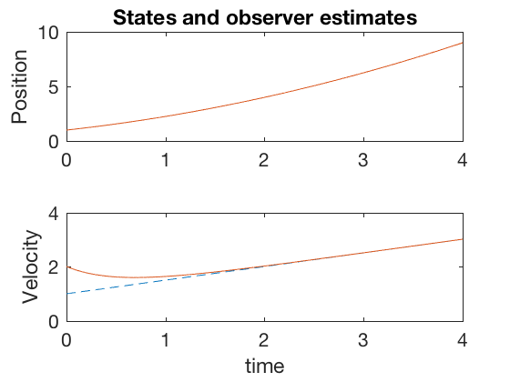

```matlab
figure;
subplot(2,1,1)
plot(t,X(1,:),'--',t,X_hat(1,:))
title('States and observer estimates')
ylabel('Position')
subplot(2,1,2)
plot(t,X(2,:),'--',t,X_hat(2,:))
ylabel('Velocity')
xlabel('time')
```

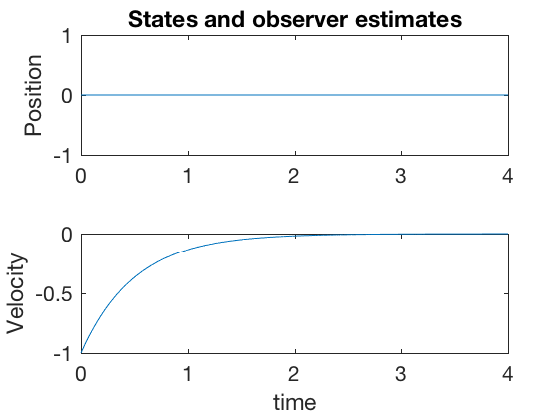

```matlab
figure;
subplot(2,1,1)
plot(t,X(1,:)-X_hat(1,:))
title('States and observer estimates')
ylabel('Position')
subplot(2,1,2)
plot(t,X(2,:)-X_hat(2,:))
ylabel('Velocity')
xlabel('time')
```

### Separation principle (short for principle of separation of estimation and control)

Separation principle states that under some assumptions the problem of designing an optimal feedback controller for a stochastic system can be solved by designing an observer for the state of the system, which feeds into a deterministic controller for the system. This allows us to break the problem into two separate parts, one for state estimation and one control.

#### Proof: Separation principle

Consider a system given by,

$$ \dot{X} = AX + Bu $$

with measurement,

$$ y = CX + Du . $$

with the observer model,

$$ \dot{\hat{X}} = A\hat{X} + Bu + L (y- C \hat{X} - Du )$$

And say the control is given by,

$$ u = - K \hat{X}. $$

We now investigate stability of the combined controller-estimator system, to do so, define the error between state and estimate,

$$ e = X - \hat{X}. $$

Taking difference between observer and state estimate model gives,

$$ \dot{X} - \dot{\hat{X}} = (AX + Bu ) - (A\hat{X} + Bu + L (y- C \hat{X} - Du ))$$$$ \dot{e} = (A - LC ) e $$

The state dynamics equation with control \( u = -K \hat{X} \) becomes,

$$ \dot{X} = AX + Bu = AX - BK \hat{X} = (A - BK)X +BK e $$

Therefore, the complete observer-state system becomes,

$$ \left[\begin{array}{c} \dot{X} \\ \dot{e}\end{array}\right] = \left[\begin{array}{cc} (A - BK) & BK \\ 0 & (A - LC ) \end{array}\right] \left[\begin{array}{c} X \\ e\end{array}\right] $$

As the combined matrix is upper triangular, the poles of the state system have no effect on the poles of the observer system.

#### Example 1:

Consider the system given by,

$$ \dot{X} = \left[ \begin{array}{cc} 0 & 1 \\ 0 & 0 \end{array} \right] X + \left[ \begin{array}{c} 0 \\ 1 \end{array} \right] u $$

with measurement

$$ y = \left[ \begin{array}{cc} 1 & 0 \end{array} \right] X . $$

and control

$$ u = -8 \hat{X} - 2 \hat{\dot{X}} $$

We design a full state observer, with poles at -10 and -15.

```matlab
clc; close all;clear all

A = [0 1 ; 0 0];
B = [0 ; 1];
C = [1 0];

p = [-10;-15];

L_t = place(A',C',p);
L = L_t';
t = 0:0.001:5;
dt = t(2) - t(1);
X(:,1) = [1;1];
y(:,1) = C*X;

X_hat(:,1) = [0;0];
y_hat(:,1) = C*X_hat;
for i = 2:length(t)
    u = [-8 -2]*(X_hat(:,i-1));

    X(:,i) = X(:,i-1)  +dt * (A*X(:,i-1) + B*u);
    y(:,i) = C*X(:,i) ;

    X_hat(:,i) = X_hat(:,i-1)  +dt * (A*X_hat(:,i-1) + B*u +L*(y(:,i-1)-y_hat(:,i-1)));
    y_hat(:,i) = C*X_hat(:,i) ;
end
```

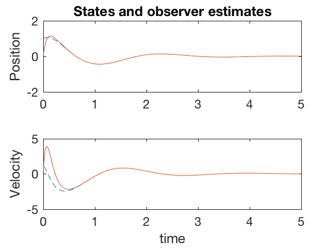

```matlab
figure;
subplot(2,1,1)
plot(t,X(1,:),'--',t,X_hat(1,:))
title('States and observer estimates')
ylabel('Position')
subplot(2,1,2)
plot(t,X(2,:),'--',t,X_hat(2,:))
ylabel('Velocity')
xlabel('time')
```

### Conclusion

- Two techniques for designing observers
- Full-order estimates all the states
- Reduced-order estimates only the unmeasured states
- Separation principle allows us to design observer and controller separately.